# Example 2: Bank term deposit subscription forecast

Author: Gurakuqi Jurgen

The dataset bank-deposit.csv includes 5 variables about a marketing campaign consisting in phone calls to convince clients to subscribe a bank term deposit.

Available variables:

subscribed the client subscribed the term deposit?

age;

education with levels “unknown”,“primary”, “secondary”, “tertiary”;

balance average yearly balance, in euros;

loan current personal loans?

Fit a model to predict if the client will subscribe the term deposit using the available variables. Describe your results and give some illustrations.

First, we read the data, then we show 6 rows of the dataset to understand how the variables of the dataset are populated:

```r
bankDeposit <- read.csv("bank-deposit.csv")
head(bankDeposit)
```

```
##   subscribed age education balance loan
## 1      FALSE  30   primary    1787   no
## 2      FALSE  33 secondary    4789  yes
## 3      FALSE  35  tertiary    1350   no
## 4      FALSE  30  tertiary    1476  yes
## 5      FALSE  59 secondary       0   no
## 6      FALSE  35  tertiary     747   no
```

We also print the data to understand how the data is distributed and if some variables need to be factorized:

```r
summary(bankDeposit)
```

```
##  subscribed           age         education            balance
##  Mode :logical   Min.   :19.00   Length:4521        Min.   :-3313
##  FALSE:4000      1st Qu.:33.00   Class :character   1st Qu.:   69
##  TRUE :521       Median :39.00   Mode  :character   Median :  444
##                  Mean   :41.17                      Mean   : 1423
##                  3rd Qu.:49.00                      3rd Qu.: 1480
##                  Max.   :87.00                      Max.   :71188
##      loan
##  Length:4521
##  Class :character
##  Mode  :character
##
##
##
```

As we can see, there are categorical variables which need to be transformed into factors:

```r
bankDeposit$loan <- factor(bankDeposit$loan)
bankDeposit$education <- factor(bankDeposit$education)
bankDeposit$subscribed <- factor(bankDeposit$subscribed)
summary(bankDeposit)
```

```
##  subscribed        age            education       balance       loan
##  FALSE:4000   Min.   :19.00   primary  : 678   Min.   :-3313   no :3830
##  TRUE : 521   1st Qu.:33.00   secondary:2306   1st Qu.:   69   yes: 691
##               Median :39.00   tertiary :1350   Median :  444
##               Mean   :41.17   unknown  : 187   Mean   : 1423
##               3rd Qu.:49.00                    3rd Qu.: 1480
##               Max.   :87.00                    Max.   :71188
```

Split **bankDeposit** randomly in two subsets for testing and training:

```r
set.seed(123)
id <- sample(x = nrow(bankDeposit), size = nrow(bankDeposit) / 2)
bankDeposit.train <- bankDeposit[id, ]
bankDeposit.test <- bankDeposit[-id, ]
```

```r
glm.fit <- glm(subscribed ~ loan + balance + age + education, data = bankDeposit.train, family = binomial)
summary(glm.fit)
```

```
##
## Call:
## glm(formula = subscribed ~ loan + balance + age + education,
##     family = binomial, data = bankDeposit.train)
##
## Coefficients:
##                      Estimate Std. Error z value Pr(>|z|)
## (Intercept)        -3.094e+00  3.562e-01  -8.687  < 2e-16 ***
## loanyes            -8.520e-01  2.363e-01  -3.606 0.000311 ***
## balance             5.073e-06  2.093e-05   0.242 0.808504
## age                 2.010e-02  6.186e-03   3.250 0.001155 **
## educationsecondary  2.607e-01  2.109e-01   1.236 0.216538
## educationtertiary   6.378e-01  2.176e-01   2.931 0.003373 **
## educationunknown   -1.055e-01  4.145e-01  -0.255 0.799033
## ---
## Signif. codes:  0 '***' 0.001 '**' 0.01 '*' 0.05 '.' 0.1 ' ' 1
##
## (Dispersion parameter for binomial family taken to be 1)
##
##     Null deviance: 1653.7  on 2259  degrees of freedom
## Residual deviance: 1617.2  on 2253  degrees of freedom
## AIC: 1631.2
##
## Number of Fisher Scoring iterations: 5
```

As we can see in the summary:

- The intercept is strongly significant and negatively related to the response.
- **loanYes** is *strongly* significant, and *negatively* related to the response.
- **balance** is *not* significant, and *positively* related to the response.
- **age** is significant, and *positively* related to the response.
- **education** is significant for tertiary, and not significant for the other values. Except for unknwon, the values of education are positively related to the response (and also except for primary, which is included in the intercept)
- The $AIC$ is *1631.2*.

We check also the effect plots of glm.fit to confirm what we have seen in the model’s summary:

```r
library(effects)
```

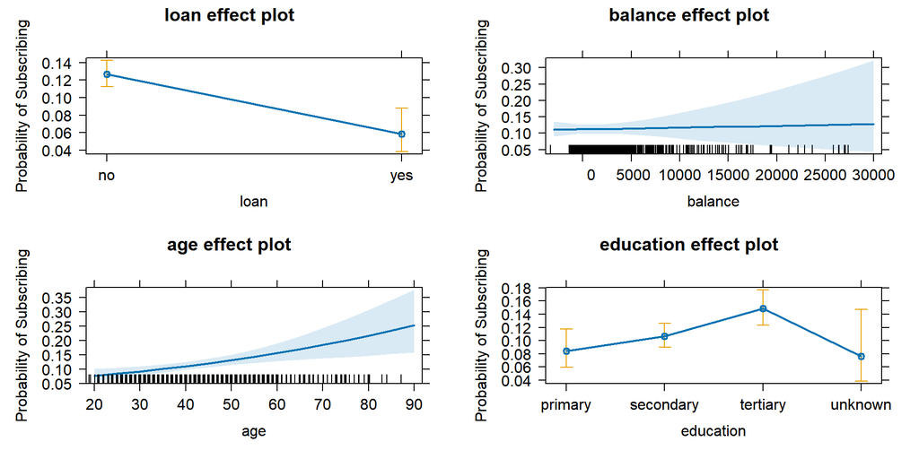

```r
plot(allEffects(glm.fit), ylab = "Probability of Subscribing",
     rescale.axis = FALSE)
```

The plots show that:

- **loan** is *strongly* significant, in fact when it changes from no to yes, or viceversa, there is a strong decrease/increase in the response.
- **balance** is *not* significant, in fact to any increment of it there isn’t any visible change in the response.
- **age** is significant, in fact to any increment of it corresponds a visible increment in the response.
- **education** is significant, as by changing from primary to secondary there is a lightly visible increase, changing to tertiare a more visible increase, but to unknown a possible decrease, but very unclear.

The summary and the Effect plots have shown how much significant are the predictors, so now predict the **Subscribed status** for the test data:

```r
glm.probs <- predict(glm.fit, newdata = bankDeposit.test, type = "response")
```

We compute the ROC curve in order to obtain through the *coords* function the best threshold, which is obtained from the best point of the ROC curve corresponding to the maximum of the sum of sensitivity and specificity (in order to obtain the best Accuracy):

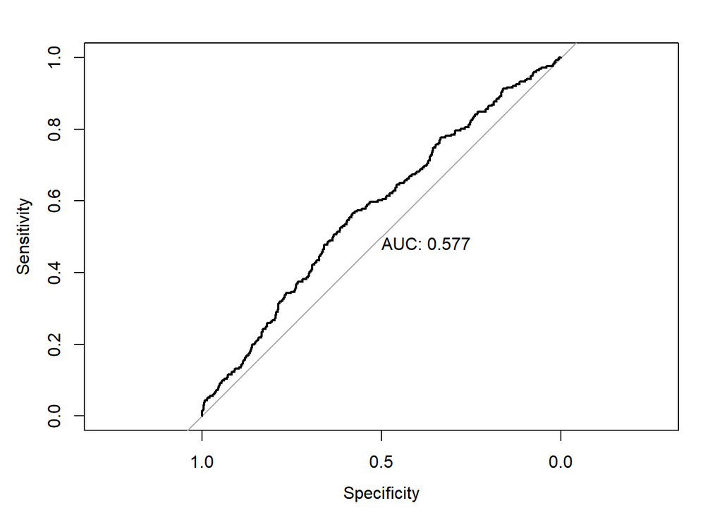

```r
library(pROC)
glm.roc <- roc(bankDeposit.test$subscribed ~ glm.probs,
               plot = TRUE,
               print.auc = TRUE)
```

```r
coords(glm.roc, x = "best", ret = "all")
```

```
##           threshold specificity sensitivity  accuracy   tn  tp  fn  fp
## threshold 0.1221101   0.5800995   0.5657371 0.5785051 1166 142 109 844
##                 npv       ppv       fdr       fpr       tpr       tnr       fnr
## threshold 0.9145098 0.1440162 0.8559838 0.4199005 0.5657371 0.5800995 0.4342629
##           1-specificity 1-sensitivity 1-accuracy     1-npv     1-ppv precision
## threshold     0.4199005     0.4342629  0.4214949 0.0854902 0.8559838 0.1440162
##              recall   youden closest.topleft
## threshold 0.5657371 1.145837       0.3649007
```

According to the output of **coords**, the optimal choice corresponds to a threshold of `0.12` with a corresponding accuracy of `57.85`% (and $58%$ specificity and $57%$ sensitivity).

### LDA: Linear Discriminant Analysis

In order to see id QDA and LDA can do better with this model, we fit it again with them. First we fit the same previous model with the Linear Discriminant Analysis:

```r
library(MASS)
lda.fit <- lda(subscribed ~ loan + balance + age + education,
               data = bankDeposit.train)
lda.fit
```

```
## Call:
## lda(subscribed ~ loan + balance + age + education, data = bankDeposit.train)
##
## Prior probabilities of groups:
##    FALSE     TRUE
## 0.880531 0.119469
##
## Group means:
##          loanyes  balance      age educationsecondary educationtertiary
## FALSE 0.16633166 1463.637 41.27085          0.5120603         0.2949749
## TRUE  0.07777778 1648.367 43.15926          0.4555556         0.3888889
##       educationunknown
## FALSE       0.03969849
## TRUE        0.02962963
##
## Coefficients of linear discriminants:
##                              LD1
## loanyes            -1.742288e+00
## balance             1.584992e-05
## age                 5.426351e-02
## educationsecondary  6.545140e-01
## educationtertiary   1.690684e+00
## educationunknown   -2.576387e-01
```

Now predict the test data:

```r
lda.preds <- predict(lda.fit, newdata = bankDeposit.test)
```

We build a ROC curve for the LDA to look for the best threshold:

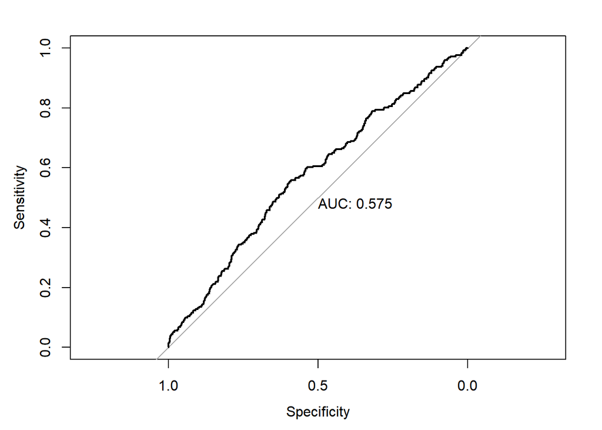

```r
lda.roc <- roc(bankDeposit.test$subscribed ~ lda.preds$posterior[, 2],
               plot = TRUE,
               print.auc = TRUE)
```

```r
coords(lda.roc, x = "best", ret = "all")
```

```
##           threshold specificity sensitivity  accuracy   tn  tp  fn  fp
## threshold 0.1218004   0.5960199   0.5537849 0.5913313 1198 139 112 812
##                 npv       ppv       fdr       fpr       tpr       tnr       fnr
## threshold 0.9145038 0.1461619 0.8538381 0.4039801 0.5537849 0.5960199 0.4462151
##           1-specificity 1-sensitivity 1-accuracy      1-npv     1-ppv precision
## threshold     0.4039801     0.4462151  0.4086687 0.08549618 0.8538381 0.1461619
##              recall   youden closest.topleft
## threshold 0.5537849 1.149805       0.3623079
```

The best choice for the threshold of linear discriminant analysis yields an accuracy of `59.13`%.

### QDA: Quadratic Discriminant Analysis

We fit now the previous model using the Quadratic discriminant analysis:

```r
library(MASS)
qda.fit <- qda(subscribed ~ loan + balance + age + education,
               data = bankDeposit.train)
qda.fit
```

```
## Call:
## qda(subscribed ~ loan + balance + age + education, data = bankDeposit.train)
##
## Prior probabilities of groups:
##    FALSE     TRUE
## 0.880531 0.119469
##
## Group means:
##          loanyes  balance      age educationsecondary educationtertiary
## FALSE 0.16633166 1463.637 41.27085          0.5120603         0.2949749
## TRUE  0.07777778 1648.367 43.15926          0.4555556         0.3888889
##       educationunknown
## FALSE       0.03969849
## TRUE        0.02962963
```

We predict the test data in order to compute the ROC Curve, and so the best threshold (to find the Accuracy):

```r
qda.preds <- predict(qda.fit, newdata = bankDeposit.test)
table(preds = qda.preds$class, true = bankDeposit.test$subscribed)
```

```
##        true
## preds   FALSE TRUE
##   FALSE  1988  245
##   TRUE     22    6
```

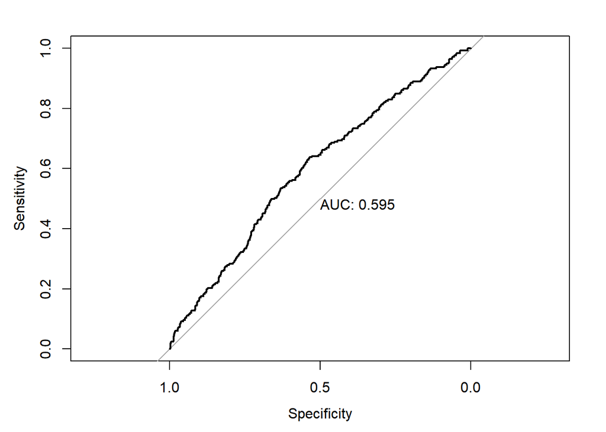

```r
qda.roc <- roc(bankDeposit.test$subscribed ~ qda.preds$posterior[, 2],
               plot = TRUE,
               print.auc = TRUE)
```

```r
coords(qda.roc, x = "best", ret = "all")
```

```
##           threshold specificity sensitivity accuracy   tn  tp fn  fp       npv
## threshold 0.1487157   0.5437811   0.6294821 0.553295 1093 158 93 917 0.9215852
##                 ppv       fdr       fpr       tpr       tnr       fnr
## threshold 0.1469767 0.8530233 0.4562189 0.6294821 0.5437811 0.3705179
##           1-specificity 1-sensitivity 1-accuracy      1-npv     1-ppv precision
## threshold     0.4562189     0.3705179   0.446705 0.07841484 0.8530233 0.1469767
##              recall   youden closest.topleft
## threshold 0.6294821 1.173263       0.3454192
```

The best choice for the threshold of the quadratic discriminant analysis yields an accuracy of `55.33`%.

### RANKING

We can rank now the classification methods for the **bankDeposit** data in terms of accuracy:

1. LDA `59.13`%
2. Logistic Regression `57.85`%
3. QDA `55.33`%

We can now compute some predictions with the LDA fit, as it shows a better accuracy:

```r
predict(
  lda.fit,
  newdata = data.frame(
    loan = "no",
    balance = 2000,
    age = 60,
    education = "tertiary"
  )
)$posterior
```

```
##      FALSE     TRUE
## 1 0.774396 0.225604
```

```r
predict(
  lda.fit,
  newdata = data.frame(
    loan = "no",
    balance = 5000,
    age = 60,
    education = "tertiary"
  )
)$posterior
```

```
##       FALSE      TRUE
## 1 0.7711894 0.2288106
```

```r
predict(
  lda.fit,
  newdata = data.frame(
    loan = "no",
    balance = 2000,
    age = 30,
    education = "tertiary"
  )
)$posterior
```

```
##       FALSE      TRUE
## 1 0.8651268 0.1348732
```

```r
predict(
  lda.fit,
  newdata = data.frame(
    loan = "no",
    balance = 2000,
    age = 60,
    education = "primary"
  )
)$posterior
```

```
##       FALSE      TRUE
## 1 0.8679156 0.1320844
```

```r
predict(
  lda.fit,
  newdata = data.frame(
    loan = "yes",
    balance = 2000,
    age = 60,
    education = "primary"
  )
)$posterior
```

```
##       FALSE       TRUE
## 1 0.9276959 0.07230406
```

```r
predict(
  lda.fit,
  newdata = data.frame(
    loan = "no",
    balance = 2000,
    age = 30,
    education = "primary"
  )
)$posterior
```

```
##       FALSE       TRUE
## 1 0.9246932 0.07530677
```

```r
predict(
  lda.fit,
  newdata = data.frame(
    loan = "no",
    balance = 500,
    age = 30,
    education = "primary"
  )
)$posterior
```

```
##       FALSE       TRUE
## 1 0.9253266 0.07467336
```

As we can see:

- Balance seems to not affect the response, in fact in the last two examples there was a large change in the balance, but the response is nearly the same.
- The age is influent, in fact decreasing it to 30 years causes a very visible change in the response.
- Loan is strongly influent, as its change from No to Yes changes largely the response.